# DATA 606 Data Project

#### Cramer’s V for `IncomeBands`

```r
#require(vcd)
assocstats(xtabs( ~  IncomeBands +USES_Oxford, data=comma4bands))
```

```
##                     X^2 df P(> X^2)
## Likelihood Ratio 10.996  4 0.026609
## Pearson          10.755  4 0.029458
##
## Phi-Coefficient   : NA
## Contingency Coeff.: 0.113
## Cramer's V        : 0.114
```

```r
# Cramer's V
#require(questionr)
cramer.v(xtabs( ~  IncomeBands +USES_Oxford, data=comma4bands))
```

```
## [1] 0.113971
```

The result here, 0.113971, is not as strong as those computed above with respect to `CARE_Oxford` and `AgeBands`.

#### Compute confidence intervals on Cramer’s V for `IncomeBands`

```
##       r lower.ci upper.ci
## 1 0.114  0.07079   0.1884
```

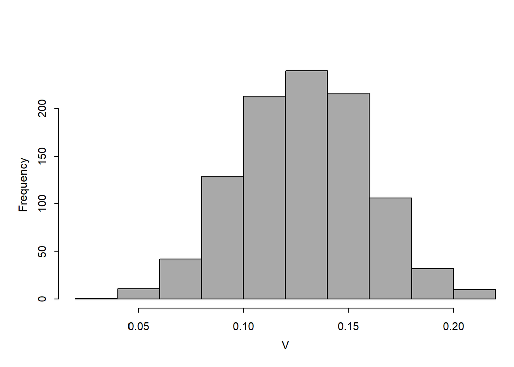

```r
#require(rcompanion)
cramerV(xtabs( ~  IncomeBands +USES_Oxford, data=comma4bands),ci=TRUE,conf=0.95,histogram=T,R=1000)
```

The above result displays the confidence interval on Cramer’s V for `IncomeBands` vs. `USES_Oxford`, based upon 1000 bootstrap samples. (The values will fluctuate slightly across runs.)

The results here are substantially lower than those for the variables considered above. However, note that here we are not seeking to determine whether or not the confidence interval covers zero – because Cramer’s V cannot be negative. The test of significance is determined by the Chi-Squared statistic and the associated p-value, while Cramer’s V illustrates the strength of the relationship, assuming significance has been established.

### Part 5 - Conclusion

The dataset indicates a negative correlation between usage of the Oxford comma and Age of the participant, with younger people most likely to use the Oxford Comma. In retrospect, it would have been preferable to have a dataset with more granularity on the quantitative variables (`Age` and `Income`) rather than what was available, with such items folded into the 4 and 5 bands (respectively) provided.

One question is whether similar results would be obtained if we treated the Quantitative variables (Age and Income) as numeric rather than categorical by imputing specific numeric figures to each observation (e.g, by adding random jitter to the midpoint of the band, or by randomly simulating such variables within each respective band).

Numerical results from such imputation were inconclusive and have been dropped from the report. (The scatterplots shown above use the jittered values only for display of the points; the calculation of each regression line imputed the midpoint value for each observation in its respective band.)

### *References*

1. Hickey, Walt, “Elitist, Superfluous, Or Popular? We Polled Americans on the Oxford Comma” (June 17, 2014), FiveThirtyEight.com . Retrieved May 15, 2019, from https://fivethirtyeight.com/features/elitist-superfluous-or-popular-we-polled-americans-on-the-oxford-comma/.
2. FiveThirtyEight.com survey of Oxford Comma Usage (2014, June). Retrieved May 15, 2019, from https://raw.githubusercontent.com/fivethirtyeight/data/master/comma-survey/comma-survey.csv.
3. Diez, D. M., Barr, C. D., & Cetinkaya-Rundel, M. (2012). OpenIntro statistics. Lexington, KY: CreateSpace. Can be downloaded from https://www.openintro.org/stat/textbook.php?stat_book=os
4. Yampol, M. (May, 2019). GitHub. from https://github.com/myampol/MY606/tree/master/
5. Victor, Daniel, “Lack of Oxford Comma Could Cost Maine Company Millions in Overtime Dispute” (March 16, 2017), New York Times. Retrieved on May 15, 2019 from https://www.nytimes.com/2017/03/16/us/oxford-comma-lawsuit.html
6. Victor, Daniel, “Oxford Comma Dispute Is Settled as Maine Drivers Get $5 Million” (February 9, 2018), New York Times. Retrieved on May 15, 2019 from https://www.nytimes.com/2018/02/09/us/oxford-comma-maine.html
7. O’Connor v. Oakhurst Dairy, No. 16-1901 (1st Cir. 2017). Retrieved on May 15, 2019 from https://law.justia.com/cases/federal/appellate-courts/ca1/16-1901/16-1901-2017-03-13.html